# Forecasting with Stationary Series

Muhammed Ikbal Baykal - IE360 - Fall 2020

# Introduction

There exists a market in Turkey about the production and the distribution of the electricity. EPIAS is the controller of this market. Energy Exchange Istanbul (EXIST) within EPIAS aims to plan, establish, develop and manage energy market within the market operation license in an effective, transparent, reliable manner that fulfills the requirements of energy market and to be an energy market management that procures reliable reference price without discriminating equivalent parties and maximizes the liquidity with increasing number of market participants, product range and trading volume as well as allowing to merchandise by means of market merger. A lot of data can be seen in [EPIAS Transperency Platform](https://seffaflik.epias.com.tr/transparency/tuketim/gerceklesen-tuketim/gercek-zamanli-tuketim.xhtml).

# Data

## Data Manipulation

First of all, necessary libraries are added.

```r
library(dplyr)
library(lubridate)
library(readxl)
library(data.table)
library(forecast)
library(urca)
library(ggplot2)
```

After libraries are added, data from EPIAS are read and some manipulations are done to make data useful.

```r
consumption <- as.data.table(read_excel("hw4data.xlsx"))
colnames(consumption) = c("Date", "Hour", "Consumption")
consumption[,Consumption:=gsub('\\.', '', Consumption)]
consumption[,Consumption:=gsub('\\,', '.', Consumption)]
consumption$Date <- as.Date(consumption$Date, format = "%d.%m.%Y")
consumption$Hour <- rep(seq(0,23, by=1), times = nrow(consumption)/24)
consumption[,Consumption:=as.numeric(Consumption)]
head(consumption, 5)
```

```
##          Date Hour Consumption
## 1: 2017-01-01    0    27223.06
## 2: 2017-01-01    1    25825.90
## 3: 2017-01-01    2    24252.68
## 4: 2017-01-01    3    22915.47
## 5: 2017-01-01    4    22356.99
```

Now, data are in useful format. We will made predictions on daily basis. So, we need to convert the data to daily consumption data by using mean of the hourly consumption data.

```r
dailyconsumption=consumption[,list(meanconsumption=mean(Consumption, na.rm = T)),by=list(Date)]
head(dailyconsumption, 5)
```

```
##          Date meanconsumption
## 1: 2017-01-01        27099.66
## 2: 2017-01-02        33141.88
## 3: 2017-01-03        34769.59
## 4: 2017-01-04        35250.70
## 5: 2017-01-05        35109.35
```

Now, data are ready. We can continue with some visualization.

## Data Visualization

It is useful to plot some graphs to understand the data we have.

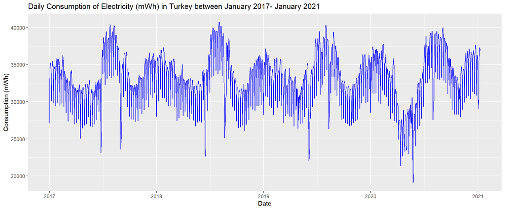

```r
ggplot(dailyconsumption, aes(x=Date, y=meanconsumption)) + geom_line(size = 0.5, color="blue") +
        labs(title = "Daily Consumption of Electricity (mWh) in Turkey between January 2017- January 2021", x = "Date", y = "Consumption (mWh)")
```

Let us see the two weeks period.

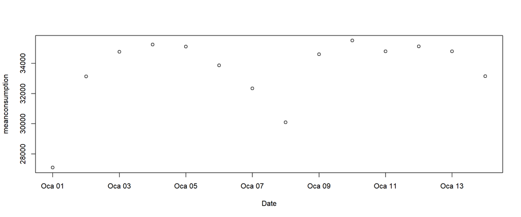

```r
plot(dailyconsumption[1:14])
```

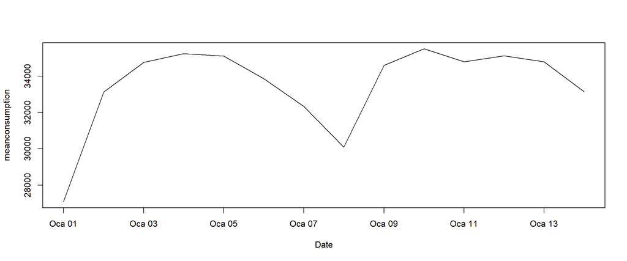

```r
plot(dailyconsumption[1:14], type="l")
```

The seasonality can be seen from the above graphs. We can see the difference between seasons, Some outliers can also be seen in the graphs. The steep decreases are usually religious holidays. In 2020, after March, Covid-19 effect for the electricity consumption can be seen. It is probably because of industrial shutdowns. Second and third graphs show the similarity of electricity consumption between two weeks.

## Data Analysis

Now, lagged values will be examined. They are important in such transformations. “Autocorrelation and Partial Autocorrelation Plots of Daily Mean Electricity Consumption” will be provided below.

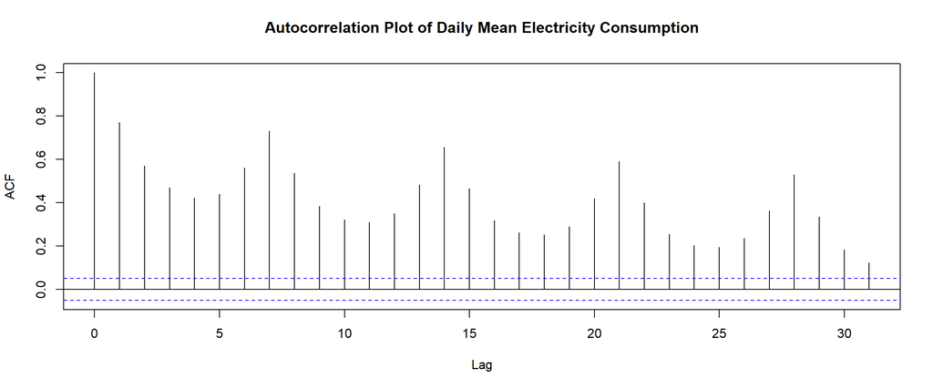

```r
plot(acf(dailyconsumption$meanconsumption, plot=F), main = "Autocorrelation Plot of Daily Mean Electricity Consumption")
```

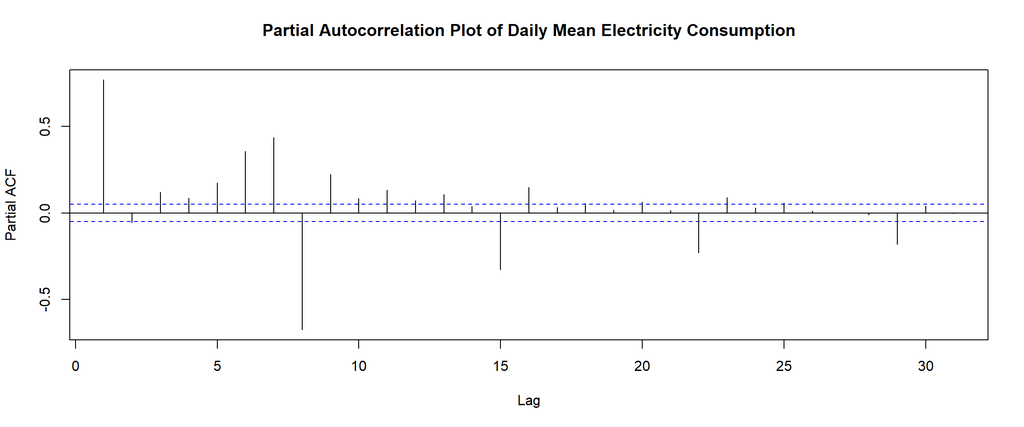

```r
plot(pacf(dailyconsumption$meanconsumption, plot=F), main = "Partial Autocorrelation Plot of Daily Mean Electricity Consumption")
```

From the first graph, it can be concluded that positive autocorrelation can be found in long terms. Lag 1 and lag 7 periods seem to be important factors in the graph. A strong weekly seasonality can be found. In the second graph, lag 1 and lag 7 effects can be seen more clearly. Lag 7 corresponds to weekly effect whereas lag 1 may correspond to a total increase.

Now, let us see the KPSS test of consumption.

```r
summary(ur.kpss(dailyconsumption$meanconsumption))
```

```
##
## #######################
## # KPSS Unit Root Test #
## #######################
##
## Test is of type: mu with 7 lags.
##
## Value of test-statistic is: 0.1457
##
## Critical value for a significance level of:
##                 10pct  5pct 2.5pct  1pct
## critical values 0.347 0.463  0.574 0.739
```

The value is under all critical values but some steps can be taken to get a more acceptable value. Now the weekly effect will be deleted and test will be applied once more.

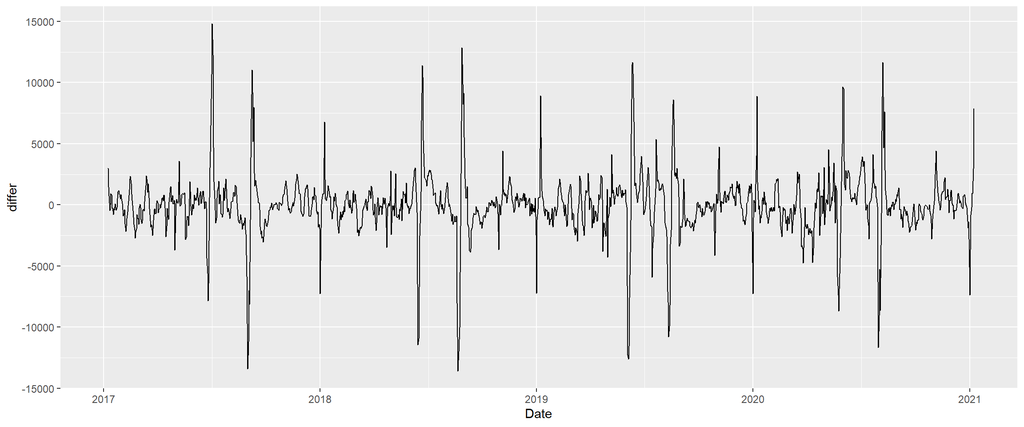

```r
dailyconsumption[,differ:=meanconsumption-shift(meanconsumption,7)]
ggplot(dailyconsumption,aes(x=Date)) + geom_line(aes(y=differ))
```

```r
summary(ur.kpss(dailyconsumption$differ))
```

```
##
## #######################
## # KPSS Unit Root Test #
## #######################
##
## Test is of type: mu with 7 lags.
##
## Value of test-statistic is: 0.0121
##
## Critical value for a significance level of:
##                 10pct  5pct 2.5pct  1pct
## critical values 0.347 0.463  0.574 0.739
```

It can be concluded that a decreased value can be obtained by differencing weekly. Now, let us consider lag 1 values. Lag 7 and lag 1 values will be considered according to their weights.

```r
dailyconsumption[,lag1:=shift(meanconsumption,1)]
dailyconsumption[,lag7:=shift(meanconsumption,7)]
dailyconsumption[,differencinglag1and7:=meanconsumption-0.3*lag7-0.7*lag1]
summary(ur.kpss(dailyconsumption$differencinglag1and7))
```

```
##
## #######################
## # KPSS Unit Root Test #
## #######################
##
## Test is of type: mu with 7 lags.
##
## Value of test-statistic is: 0.0126
##
## Critical value for a significance level of:
##                 10pct  5pct 2.5pct  1pct
## critical values 0.347 0.463  0.574 0.739
```

A better result could not be obtained, now let us examine the outliers. A new column is added and 1 is put if the day is religious or formal holiday. (Others=0) Each special days will be added manually.

```r
dailyconsumption[, specialday:=0]

dailyconsumption[ Date == "2017-01-01" ,specialday := 1]
dailyconsumption[ Date == "2017-04-23" ,specialday := 1]
dailyconsumption[ Date == "2017-05-01" ,specialday := 1]
dailyconsumption[ Date == "2017-05-19" ,specialday := 1]
dailyconsumption[ Date == "2017-06-24" ,specialday := 1]
dailyconsumption[ Date == "2017-06-25" ,specialday := 1]
dailyconsumption[ Date == "2017-06-26" ,specialday := 1]
dailyconsumption[ Date == "2017-06-27" ,specialday := 1]
dailyconsumption[ Date == "2017-07-15" ,specialday := 1]
dailyconsumption[ Date == "2017-08-30" ,specialday := 1]
dailyconsumption[ Date == "2017-08-31" ,specialday := 1]
dailyconsumption[ Date == "2017-09-01" ,specialday := 1]
dailyconsumption[ Date == "2017-09-02" ,specialday := 1]
dailyconsumption[ Date == "2017-09-03" ,specialday := 1]
dailyconsumption[ Date == "2017-09-04" ,specialday := 1]
dailyconsumption[ Date == "2017-10-29" ,specialday := 1]
dailyconsumption[ Date == "2017-12-31" ,specialday := 1]

dailyconsumption[ Date == "2018-01-01" ,specialday := 1]
dailyconsumption[ Date == "2018-04-23" ,specialday := 1]
dailyconsumption[ Date == "2018-05-01" ,specialday := 1]
dailyconsumption[ Date == "2018-05-19" ,specialday := 1]
dailyconsumption[ Date == "2018-06-14" ,specialday := 1]
dailyconsumption[ Date == "2018-06-15" ,specialday := 1]
dailyconsumption[ Date == "2018-06-16" ,specialday := 1]
dailyconsumption[ Date == "2018-06-17" ,specialday := 1]
dailyconsumption[ Date == "2018-07-15" ,specialday := 1]
dailyconsumption[ Date == "2018-08-20" ,specialday := 1]
dailyconsumption[ Date == "2018-08-21" ,specialday := 1]
dailyconsumption[ Date == "2018-08-22" ,specialday := 1]
dailyconsumption[ Date == "2018-08-23" ,specialday := 1]
dailyconsumption[ Date == "2018-08-24" ,specialday := 1]
dailyconsumption[ Date == "2018-08-30" ,specialday := 1]
dailyconsumption[ Date == "2018-10-29" ,specialday := 1]
dailyconsumption[ Date == "2018-12-31" ,specialday := 1]

dailyconsumption[ Date == "2019-01-01" ,specialday := 1]
dailyconsumption[ Date == "2019-04-23" ,specialday := 1]
dailyconsumption[ Date == "2019-05-01" ,specialday := 1]
dailyconsumption[ Date == "2019-05-19" ,specialday := 1]
dailyconsumption[ Date == "2019-06-04" ,specialday := 1]
dailyconsumption[ Date == "2019-06-05" ,specialday := 1]
dailyconsumption[ Date == "2019-06-06" ,specialday := 1]
dailyconsumption[ Date == "2019-06-07" ,specialday := 1]
dailyconsumption[ Date == "2019-07-15" ,specialday := 1]
dailyconsumption[ Date == "2019-08-10" ,specialday := 1]
dailyconsumption[ Date == "2019-08-11" ,specialday := 1]
dailyconsumption[ Date == "2019-08-12" ,specialday := 1]
dailyconsumption[ Date == "2019-08-13" ,specialday := 1]
dailyconsumption[ Date == "2019-08-14" ,specialday := 1]
dailyconsumption[ Date == "2019-08-30" ,specialday := 1]
dailyconsumption[ Date == "2019-10-29" ,specialday := 1]
dailyconsumption[ Date == "2019-12-31" ,specialday := 1]

dailyconsumption[ Date == "2020-01-01" ,specialday := 1]
dailyconsumption[ Date == "2020-04-23" ,specialday := 1]
dailyconsumption[ Date == "2020-05-01" ,specialday := 1]
dailyconsumption[ Date == "2020-05-19" ,specialday := 1]
dailyconsumption[ Date == "2020-05-23" ,specialday := 1]
dailyconsumption[ Date == "2020-05-24" ,specialday := 1]
dailyconsumption[ Date == "2020-05-25" ,specialday := 1]
dailyconsumption[ Date == "2020-05-26" ,specialday := 1]
dailyconsumption[ Date == "2020-07-15" ,specialday := 1]
dailyconsumption[ Date == "2020-07-30" ,specialday := 1]
dailyconsumption[ Date == "2020-07-31" ,specialday := 1]
dailyconsumption[ Date == "2020-08-01" ,specialday := 1]
dailyconsumption[ Date == "2020-08-02" ,specialday := 1]
dailyconsumption[ Date == "2020-08-03" ,specialday := 1]
dailyconsumption[ Date == "2020-08-30" ,specialday := 1]
dailyconsumption[ Date == "2020-10-29" ,specialday := 1]
dailyconsumption[ Date == "2020-12-31" ,specialday := 1]
```

The value of these days will be changed by the mean of one week before and one week ahead values. So, the outliers will be excluded from the data. Let us see the new KPSS test value.

```r
dailyconsumption[,adjusted:=meanconsumption]
dailyconsumption[,oneweek:=shift(meanconsumption,-7)]
dailyconsumption[specialday==1, adjusted:=(lag7+oneweek)/2]

dailyconsumption[,nlag1:=shift(adjusted,1)]
dailyconsumption[,nlag7:=shift(adjusted,7)]
dailyconsumption[,newdifferencinglag1and7:=adjusted-0.3*nlag7-0.7*nlag1]
summary(ur.kpss(dailyconsumption$newdifferencinglag1and7))
```

```
##
## #######################
## # KPSS Unit Root Test #
## #######################
##
## Test is of type: mu with 7 lags.
##
## Value of test-statistic is: 0.0284
##
## Critical value for a significance level of:
##                 10pct  5pct 2.5pct  1pct
## critical values 0.347 0.463  0.574 0.739
```

Better value is not obtained, the first differenced KPSS test value was better than this. Let us examine the partial autocorrelation plot.

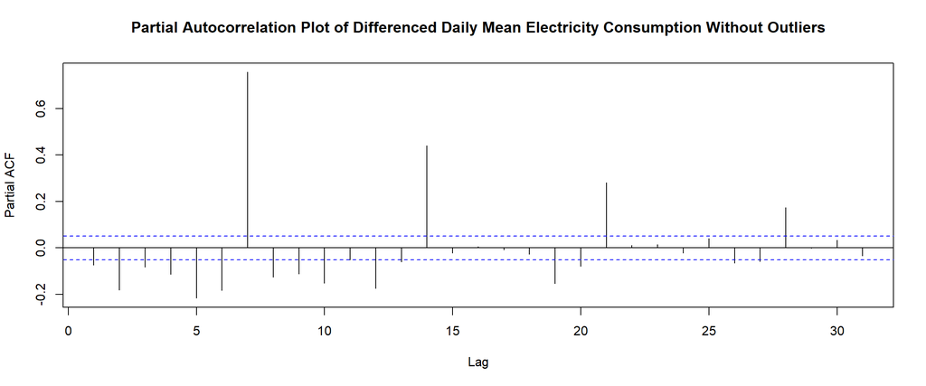

```r
plot(pacf(dailyconsumption[9:1469]$newdifferencinglag1and7, plot=F), main = "Partial Autocorrelation Plot of Differenced Daily Mean Electricity Consumption Without Outliers")
```

Lag1 problem is handled well, but still there are some problems. Day of the week effect seems to be perminent.

# Forecast

Let us construct two models. Model2 will be used to predict due to its KPSS test result.

```r
nahead=15
model1 = auto.arima(dailyconsumption$newdifferencinglag1and7, seasonal=F, trace=T)
```

```
##
##  Fitting models using approximations to speed things up...
##
##  ARIMA(2,0,2) with non-zero mean : 25735.59
##  ARIMA(0,0,0) with non-zero mean : 25897.79
##  ARIMA(1,0,0) with non-zero mean : 25888.48
##  ARIMA(0,0,1) with non-zero mean : 25887.27
##  ARIMA(0,0,0) with zero mean     : 25895.79
##  ARIMA(1,0,2) with non-zero mean : 25816.07
##  ARIMA(2,0,1) with non-zero mean : 25813.63
##  ARIMA(3,0,2) with non-zero mean : 25734.95
##  ARIMA(3,0,1) with non-zero mean : 25814.98
##  ARIMA(4,0,2) with non-zero mean : 25695.99
##  ARIMA(4,0,1) with non-zero mean : 25797.61
##  ARIMA(5,0,2) with non-zero mean : Inf
##  ARIMA(4,0,3) with non-zero mean : Inf
##  ARIMA(3,0,3) with non-zero mean : Inf
##  ARIMA(5,0,1) with non-zero mean : 25746.07
##  ARIMA(5,0,3) with non-zero mean : Inf
##  ARIMA(4,0,2) with zero mean     : 25693.97
##  ARIMA(3,0,2) with zero mean     : 25732.94
##  ARIMA(4,0,1) with zero mean     : 25795.59
##  ARIMA(5,0,2) with zero mean     : Inf
##  ARIMA(4,0,3) with zero mean     : Inf
##  ARIMA(3,0,1) with zero mean     : 25812.97
##  ARIMA(3,0,3) with zero mean     : Inf
##  ARIMA(5,0,1) with zero mean     : 25744.05
##  ARIMA(5,0,3) with zero mean     : Inf
##
##  Now re-fitting the best model(s) without approximations...
##
##  ARIMA(4,0,2) with zero mean     : 25696.16
##
##  Best model: ARIMA(4,0,2) with zero mean
```

```r
model2 = auto.arima(dailyconsumption$differ,seasonal=F,trace=T)
```

```
##
##  Fitting models using approximations to speed things up...
##
##  ARIMA(2,0,2) with non-zero mean : 25141.3
##  ARIMA(0,0,0) with non-zero mean : 27068.03
##  ARIMA(1,0,0) with non-zero mean : 25349.74
##  ARIMA(0,0,1) with non-zero mean : 25948.16
##  ARIMA(0,0,0) with zero mean     : 27066.04
##  ARIMA(1,0,2) with non-zero mean : 25226.47
##  ARIMA(2,0,1) with non-zero mean : 25142.99
##  ARIMA(3,0,2) with non-zero mean : 25145.39
##  ARIMA(2,0,3) with non-zero mean : 25091.19
##  ARIMA(1,0,3) with non-zero mean : 25207.87
##  ARIMA(3,0,3) with non-zero mean : Inf
##  ARIMA(2,0,4) with non-zero mean : Inf
##  ARIMA(1,0,4) with non-zero mean : 25171.37
##  ARIMA(3,0,4) with non-zero mean : Inf
##  ARIMA(2,0,3) with zero mean     : 25089.27
##  ARIMA(1,0,3) with zero mean     : 25205.87
##  ARIMA(2,0,2) with zero mean     : 25139.32
##  ARIMA(3,0,3) with zero mean     : Inf
##  ARIMA(2,0,4) with zero mean     : Inf
##  ARIMA(1,0,2) with zero mean     : 25224.46
##  ARIMA(1,0,4) with zero mean     : 25169.35
##  ARIMA(3,0,2) with zero mean     : 25143.4
##  ARIMA(3,0,4) with zero mean     : Inf
##
##  Now re-fitting the best model(s) without approximations...
##
##  ARIMA(2,0,3) with zero mean     : Inf
##  ARIMA(2,0,3) with non-zero mean : Inf
##  ARIMA(2,0,2) with zero mean     : 25140.13
##
##  Best model: ARIMA(2,0,2) with zero mean
```

```r
summary(model2)
```

```
## Series: dailyconsumption$differ
## ARIMA(2,0,2) with zero mean
##
## Coefficients:
##          ar1      ar2      ma1      ma2
##       1.6563  -0.7630  -0.6327  -0.0760
## s.e.  0.0308   0.0242   0.0410   0.0392
##
## sigma^2 estimated as 1711052:  log likelihood=-12565.04
## AIC=25140.08   AICc=25140.13   BIC=25166.52
##
## Training set error measures:
##                    ME     RMSE      MAE       MPE    MAPE      MASE
## Training set 6.233523 1306.281 787.6084 -1.686384 231.007 0.9304235
##                      ACF1
## Training set -0.006211503
```

Auto.arima function suggests that best choice for predictions is to use ARIMA(2,0,2) which means 2 AR and 2 MA factors will be used in the model. 15 day ahead forecast will be made.

```r
forecasted = forecast(model2,h=nahead)
print(forecasted)
```

```
##      Point Forecast      Lo 80     Hi 80      Lo 95     Hi 95
## 1470      7630.4453  5954.0839 9306.8067  5066.6718 10194.219
## 1471      6266.3092  3867.4081 8665.2103  2597.5065  9935.112
## 1472      4556.4776  1760.8497 7352.1056   280.9336  8832.022
## 1473      2765.3907  -227.4139 5758.1952 -1811.7090  7342.490
## 1474      1103.5021 -1964.2781 4171.2823 -3588.2629  5795.267
## 1475      -282.3942 -3364.9350 2800.1465 -4996.7335  4431.945
## 1476     -1309.7504 -4392.3292 1772.8285 -6024.1479  3404.647
## 1477     -1953.8529 -5046.9838 1139.2780 -6684.3884  2776.683
## 1478     -2236.7571 -5357.0909  883.5768 -7008.8958  2535.382
## 1479     -2213.8501 -5371.8293  944.1290 -7043.5625  2615.862
## 1480     -1960.0408 -5156.0409 1235.9593 -6847.9012  2927.820
## 1481     -1557.1368 -4783.7108 1669.4373 -6491.7560  3377.482
## 1482     -1083.4770 -4329.9511 2162.9970 -6048.5306  3881.577
## 1483      -606.3910 -3862.9685 2650.1864 -5586.8965  4374.114
## 1484      -177.6200 -3437.6820 3082.4421 -5163.4547  4808.215
```

These values give us the differenced forecasts. We need to make some calculations and calculate the forecasted consumption values for coming days.

```r
temporary=copy(dailyconsumption)

test=dailyconsumption[1:nahead]
test[,meanconsumption:=NA]
test$Date=max(dailyconsumption$Date)+c(1:nahead)
test[,predicteddiffer:=as.numeric(forecasted$mean)]

temporary=rbindlist(list(temporary,test),fill=T,use.names=T)
temporary[is.na(predicteddiffer),predicteddiffer:=differ] # past values are known

# transforming to the original scale
temporary[,forecastval:=predicteddiffer+shift(meanconsumption,14)]
```

Now, we need to add the actual values to be able to compare our prediction accuracy.

```r
realconsumption <- as.data.table(read_excel("hw4data3.xlsx"))
colnames(realconsumption) = c("Date", "Hour", "Consumption")
realconsumption[,Consumption:=gsub('\\.', '', Consumption)]
realconsumption[,Consumption:=gsub('\\,', '.', Consumption)]
realconsumption$Date <- as.Date(realconsumption$Date, format = "%d.%m.%Y")
realconsumption$Hour <- rep(seq(0,23, by=1), times = nrow(realconsumption)/24)
realconsumption[,Consumption:=as.numeric(Consumption)]
head(realconsumption, 5)
```

```
##          Date Hour Consumption
## 1: 2021-01-09    0    34179.62
## 2: 2021-01-09    1    32540.12
## 3: 2021-01-09    2    31207.36
## 4: 2021-01-09    3    30300.31
## 5: 2021-01-09    4    29733.83
```

```r
realdailyconsumption=realconsumption[,list(meanconsumption=mean(Consumption, na.rm = T)),by=list(Date)]
head(realdailyconsumption)
```

```
##          Date meanconsumption
## 1: 2021-01-09        34781.56
## 2: 2021-01-10        31841.90
## 3: 2021-01-11        36431.46
## 4: 2021-01-12        36897.99
## 5: 2021-01-13        37409.87
## 6: 2021-01-14        38056.05
```

Here are the mean consumption values between 09.012021 and 23.01.2021. The predicted values will be added to a new column called “predicted”. After that, error calculations will be made.

```r
realdailyconsumption[, predicted:=0]
tail(realdailyconsumption)
```

```
##          Date meanconsumption predicted
## 1: 2021-01-18        38447.89         0
## 2: 2021-01-19        39723.73         0
## 3: 2021-01-20        39960.92         0
## 4: 2021-01-21        39791.07         0
## 5: 2021-01-22        38902.97         0
## 6: 2021-01-23        35635.70         0
```

```r
realdailyconsumption$predicted <- temporary$forecastval[1470:1484]

output <- function(actual, forecasted){
  n=length(actual)
  error = actual-forecasted
  mean=mean(actual)
  sd=sd(actual)
  bias = sum(error)/sum(actual)
  mape = sum(abs(error/actual))/n
  mad = sum(abs(error))/n
  wmape = mad/mean
  l = data.frame(n,mean,sd,bias,mape,mad,wmape)
  return(l)
}

output(realdailyconsumption$meanconsumption[1:14], realdailyconsumption$predicted[1:14])
```

```
##    n     mean       sd       bias      mape      mad     wmape
## 1 14 37045.79 2567.339 0.05720735 0.1264163 4633.595 0.1250775
```

The output statistics are provided.

# Conclusion

During the study, daily electricity consumption data of Turkey were examined and stationarity processes were applied to data by using appropriate approaches. Differencing method was used as an appropriate approach. By differencing approach, we have reached an effective solution and made some predictions. Predictions were made by an ARIMA model.

In conclusion, stationarity is an effective way of finding appropriate models to data that we will make predictions upon. However, It leads to some errors or some behaviours that cannot be explained during the forecast process.

# References

- [EPIAS](https://seffaflik.epias.com.tr/transparency/tuketim/gerceklesen-tuketim/gercek-zamanli-tuketim.xhtml)
- [STHDA](http://www.sthda.com/english/)
- [Stackoverflow](https://stackoverflow.com/)

# Appendices

Click [here](https://bu-ie-360.github.io/fall20-mibaykal/files/HW4.Rmd) to reach the RMD file.